```python
import numpy as np
import matplotlib.pyplot as plt
import scipy as sp
from numpy.polynomial.polynomial import polydiv, polyder, polymul, polyadd, polyval
```

# Lab 1

**Михайло Корешков, ФІ-91**  
(*Варіант 6*)

$P(x) = 2 - x -4x^2 + 2x^3$

```python
P = np.array([2.0,-1.0,-4.0,2.0])
n = 3
```

## 1. Передпрограмний етап

### 1.1. Верхня межа додатніх коренів

```python
B = -np.inf
m = -np.inf
for i,v in enumerate(P):
    if np.abs(v) > B and v < 0:
        B, B_i = np.abs(v), i
    if i > m and v < 0:
        m = i
max_bound = 1 + np.power(B / P[n], 1/(n-m))
print("Верхня межа коренів: ", max_bound)
```

```
Верхня межа коренів:  3.0
```

### 1.2. Нижня межа додатніх коренів

```python
m = +np.inf
for i,v in enumerate(P):
    if v < 0:
        m = i
        break
m = n-m
min_positive_bound = 1/(1 + np.power(B / P[0], 1/(n-m)))
print("Нижня межа додатніх коренів: ", min_positive_bound)
```

```
Нижня межа додатніх коренів:  0.3333333333333333
```

### 1.3. Нижня межа від'ємних коренів

```python
P_neg = P * (2 * (np.arange(1,n+2) % 2) - 1)
print("Поліном після заміни x на -x: ", P_neg)
B = -np.inf
for i,v in enumerate(P_neg):
    if np.abs(v) > B and v < 0:
        B, m = np.abs(v), i
min_bound = 1 + np.power(B / P_neg[n], 1/(n-m))
print("Нижня межа коренів: ", min_bound)
```

```
Поліном після заміни x на -x:  [ 2.  1. -4. -2.]
Нижня межа коренів:  -1.0
```

## 1.4. Верхня межа від'ємних коренів

```python
m = +np.inf
for i,v in enumerate(P_neg):
    if v < 0:
        m = i
        break
m = n-m
max_negative_bound = -1/(1 + np.power(B / P[0], 1/(n-m)))
print("Верхня межа додатніх коренів: ", max_negative_bound)
```

```
Верхня межа додатніх коренів:  -0.4142135623730951
```

## 1.5. Метод Штурма

```python
P0 = P; P0
```

```
array([ 2., -1., -4.,  2.])
```

```python
P1 = polyder(P); P1
```

```
array([-1., -8.,  6.])
```

```python
# polydiv(f, g) = q, r
P2 = -polydiv(P0,P1)[1]; P2
```

```
array([-1.77777778,  2.44444444])
```

```python
P3 = -polydiv(P1,P2)[1]; P3
```

```
array([3.6446281])
```

```python
P4 = -polydiv(P2,P3)[1]; P4
```

```
array([0.])
```

```python
def sturm(x):
    return polyval(x, P0),  polyval(x, P1), polyval(x, P2), polyval(x, P3)
```

```python
sturm(min_bound) # (1)
```

```
(-3.0, 13.0, -4.222222222222222, 3.644628099173554)
```

```python
sturm(max_bound) # (2)
```

```
(17.0, 29.0, 5.555555555555556, 3.644628099173554)
```

Маємо 3 зміни знаку в (1) та 0 змін знаку в (2).  
Отже, між нижньою та верхньою межами коренів - **3 дійсних кореня**.

Степінь полінома - також 3, отже маємо **0 комплексних коренів**

```python
sturm(0) # (3)
```

```
(2.0, -1.0, -1.7777777777777777, 3.644628099173554)
```

2 зміни знаку.  
Отже **між нижньою межею та 0 маємо 1 корінь**

```python
sturm(1) # (4)
```

```
(-1.0, -3.0, 0.666666666666667, 3.644628099173554)
```

1 зміна знаку  
Отже **між 0 та 1 маємо 1 корінь**

```python
init_borders = [min_bound, 0, 1, max_bound];
print("Початкові межі між коренями: ", init_borders)
```

```
Початкові межі між коренями:  [-1.0, 0, 1, 3.0]
```

### 1.6. Графік

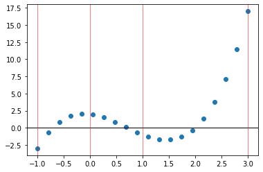

```python
X = np.linspace(min_bound, max_bound, 20)
plt.scatter(X, polyval(X, P))
plt.gca().axhline(0, c='k', lw=1)
for b in init_borders:
    plt.gca().axvline(b, c='r', lw=0.5)
```

# 2. Уточнення коренів

```python
def log(*args, **kwargs):
    if LOG:
        print(*args, **kwargs)

LOG = True
```

```python
def f(x):
    return polyval(x,P)

def df(x):
    return polyval(x, P1)
```

```python
EPS = 10e-8
```

```python
Results = dict()
```

## 2.1. Метод Бісекції

**Вхід:**

- Кінці інтервалу з гарантовано одним коренем  
  (Функція має в цьому корені змінювати знак)
- Точність $\varepsilon$

**Вихід**:

- Наближений корінь $x^*$ з точністю $|x^* - x_{true}| < \varepsilon$

```python
def bisect(f, a, b, eps, timeout=1000):
    a = float(a)
    b = float(b)
    n = 1
    log("Bisection method.")
    while np.abs(a-b) > eps and n < timeout:
        c = (a+b)/2
        fc = f(c)
        log(f"it {n}: a={a}, b={b}, c={c}, f(c)={fc} ", end='')
        sfc = np.sign(fc)
        if np.sign(f(a)) * sfc < 0:
            log("-> [a,c]")
            a, b = a, c
        elif sfc * np.sign(f(b)) < 0:
            log("-> [c,b]")
            a, b = c, b
        elif -eps < fc < eps:
            log("-> (|f(c)| < eps) -> root found!")
            return c
        else:
            log("; Something wrong. Let's shift boundaries a bit.")
            a = a+eps
            b = b+eps
        n += 1

    log("Finished. ", end='')
    if np.abs(a-b) < eps:
        log("|a-b|<eps")
    else:
        log("timeout")
    return (a+b)/2
```

```python
roots = []
for i in range(len(init_borders)-1):
    roots.append(bisect(f, init_borders[i], init_borders[i+1], EPS))

print("\nКорені, уточнені методом Бісекції: ", roots)
Results['bisection'] = roots
```

```
Bisection method.
it 1: a=-1.0, b=0.0, c=-0.5, f(c)=1.25 -> [a,c]
it 2: a=-1.0, b=-0.5, c=-0.75, f(c)=-0.34375 -> [c,b]
it 3: a=-0.75, b=-0.5, c=-0.625, f(c)=0.57421875 -> [a,c]
it 4: a=-0.75, b=-0.625, c=-0.6875, f(c)=0.14697265625 -> [a,c]
it 5: a=-0.75, b=-0.6875, c=-0.71875, f(c)=-0.09027099609375 -> [c,b]
it 6: a=-0.71875, b=-0.6875, c=-0.703125, f(c)=0.03035736083984375 -> [a,c]
it 7: a=-0.71875, b=-0.703125, c=-0.7109375, f(c)=-0.02945232391357422 -> [c,b]
it 8: a=-0.7109375, b=-0.703125, c=-0.70703125, f(c)=0.0005782842636108398 -> [a,c]
it 9: a=-0.7109375, b=-0.70703125, c=-0.708984375, f(c)=-0.01440553367137909 -> [c,b]
it 10: a=-0.708984375, b=-0.70703125, c=-0.7080078125, f(c)=-0.006905758753418922 -> [c,b]
it 11: a=-0.7080078125, b=-0.70703125, c=-0.70751953125, f(c)=-0.0031617714557796717 -> [c,b]
it 12: a=-0.70751953125, b=-0.70703125, c=-0.707275390625, f(c)=-0.0012912522361148149 -> [c,b]
it 13: a=-0.707275390625, b=-0.70703125, c=-0.7071533203125, f(c)=-0.0003563611571735237 -> [c,b]
it 14: a=-0.7071533203125, b=-0.70703125, c=-0.70709228515625, f(c)=0.00011099225912403199 -> [a,c]
it 15: a=-0.7071533203125, b=-0.70709228515625, c=-0.707122802734375, f(c)=-0.0001226767723778721 -> [c,b]
it 16: a=-0.707122802734375, b=-0.70709228515625, c=-0.7071075439453125, f(c)=-5.84033748651791e-06 -> [c,b]
it 17: a=-0.7071075439453125, b=-0.70709228515625, c=-0.7070999145507812, f(c)=5.257644060119304e-05 -> [a,c]
it 18: a=-0.7071075439453125, b=-0.7070999145507812, c=-0.7071037292480469, f(c)=2.336817150316861e-05 -> [a,c]
it 19: a=-0.7071075439453125, b=-0.7071037292480469, c=-0.7071056365966797, f(c)=8.763946995005156e-06 -> [a,c]
it 20: a=-0.7071075439453125, b=-0.7071056365966797, c=-0.7071065902709961, f(c)=1.4618122508025522e-06 -> [a,c]
it 21: a=-0.7071075439453125, b=-0.7071065902709961, c=-0.7071070671081543, f(c)=-2.1892607438012135e-06 -> [c,b]
it 22: a=-0.7071070671081543, b=-0.7071065902709961, c=-0.7071068286895752, f(c)=-3.6372377776316966e-07 -> [c,b]
it 23: a=-0.7071068286895752, b=-0.7071065902709961, c=-0.7071067094802856, f(c)=5.49044353537198e-07 -> [a,c]
it 24: a=-0.7071068286895752, b=-0.7071067094802856, c=-0.7071067690849304, f(c)=9.266031719690204e-08 -> [a,c]
Finished. |a-b|<eps
Bisection method.
it 1: a=0.0, b=1.0, c=0.5, f(c)=0.75 -> [c,b]
it 2: a=0.5, b=1.0, c=0.75, f(c)=-0.15625 -> [a,c]
it 3: a=0.5, b=0.75, c=0.625, f(c)=0.30078125 -> [c,b]
it 4: a=0.625, b=0.75, c=0.6875, f(c)=0.07177734375 -> [c,b]
it 5: a=0.6875, b=0.75, c=0.71875, f(c)=-0.04254150390625 -> [a,c]
it 6: a=0.6875, b=0.71875, c=0.703125, f(c)=0.01456451416015625 -> [c,b]
it 7: a=0.703125, b=0.71875, c=0.7109375, f(c)=-0.014004707336425781 -> [a,c]
it 8: a=0.703125, b=0.7109375, c=0.70703125, f(c)=0.00027620792388916016 -> [c,b]
it 9: a=0.70703125, b=0.7109375, c=0.708984375, f(c)=-0.006865218281745911 -> [a,c]
it 10: a=0.70703125, b=0.708984375, c=0.7080078125, f(c)=-0.0032947417348623276 -> [a,c]
it 11: a=0.70703125, b=0.7080078125, c=0.70751953125, f(c)=-0.0015093253459781408 -> [a,c]
it 12: a=0.70703125, b=0.70751953125, c=0.707275390625, f(c)=-0.0006165732338558882 -> [a,c]
it 13: a=0.70703125, b=0.707275390625, c=0.7071533203125, f(c)=-0.0001701862747722771 -> [a,c]
it 14: a=0.70703125, b=0.7071533203125, c=0.70709228515625, f(c)=5.3009920975455316e-05 -> [c,b]
it 15: a=0.70709228515625, b=0.7071533203125, c=0.707122802734375, f(c)=-5.85884029646877e-05 -> [a,c]
it 16: a=0.70709228515625, b=0.707122802734375, c=0.7071075439453125, f(c)=-2.7892974898691136e-06 -> [a,c]
it 17: a=0.70709228515625, b=0.7071075439453125, c=0.7070999145507812, f(c)=2.5110297621644406e-05 -> [c,b]
it 18: a=0.7070999145507812, b=0.7071075439453125, c=0.7071037292480469, f(c)=1.1160496535378428e-05 -> [c,b]
it 19: a=0.7071037292480469, b=0.7071075439453125, c=0.7071056365966797, f(c)=4.185598639905308e-06 -> [c,b]
it 20: a=0.7071056365966797, b=0.7071075439453125, c=0.7071065902709961, f(c)=6.981503544167822e-07 -> [c,b]
it 21: a=0.7071065902709961, b=0.7071075439453125, c=0.7071070671081543, f(c)=-1.0455736227932277e-06 -> [a,c]
it 22: a=0.7071065902709961, b=0.7071070671081543, c=0.7071068286895752, f(c)=-1.7371164817703288e-07 -> [a,c]
it 23: a=0.7071065902709961, b=0.7071068286895752, c=0.7071067094802856, f(c)=2.622193497892056e-07 -> [c,b]
it 24: a=0.7071067094802856, b=0.7071068286895752, c=0.7071067690849304, f(c)=4.425384991790793e-08 -> [c,b]
Finished. |a-b|<eps
Bisection method.
it 1: a=1.0, b=3.0, c=2.0, f(c)=0.0 -> (|f(c)| < eps) -> root found!

Корені, уточнені методом Бісекції:  [-0.7071067988872528, 0.7071067988872528, 2.0]
```

## 2.2. Метод Хорд

**Вхід:**

- Кінці інтервалу з гарантовано одним коренем  
  (Функція має в цьому корені змінювати знак)
- Точність $\varepsilon$

*Рекомендовано:*

- Монотонність
- Знакосталість другої похідної

**Вихід**:

- Наближений корінь $x^*$ з точністю $|x^* - x_{true}| < \varepsilon$

```python
def chord(f, a, b, eps, timeout=1000):
    a = float(a)
    b = float(b)
    log("Chord method.")

    def gen_c(a,b):
        fa, fb = f(a), f(b)
        c = (a*f(b) - b*f(a))/(f(b) - f(a))
        return c, fa, f(c), fb

    n = 1
    c_prev = np.inf
    c, fa, fc, fb = gen_c(a,b)
    while np.abs(fc) > eps and np.abs(c-c_prev) > eps and n < timeout:
        log(f"it {n}: a={a}, b={b}, c={c}, f(c)={fc} ", end='')
        if np.sign(fa) * np.sign(fc) < 0:
            a, b, c_prev = a, c, c
            log("-> [a,c]")
        elif np.sign(fc) * np.sign(fb) < 0:
            a, b, c_prev = c, b, c
            log("-> [c,b]")
        c, fa, fc, fb = gen_c(a,b)
        n += 1
    log("Chord method finished. ", end='')
    if np.abs(fc) < eps:
        log("(|f(c)| < eps) - root found")
    elif np.abs(c-c_prev) < eps:
        log("|c-c_prev| < eps")
    else:
        log("timeout")

    return c
```

```python
roots = []
for i in range(len(init_borders)-1):
    roots.append(chord(f, init_borders[i], init_borders[i+1], EPS))

print("\nКорені, уточнені методом Хорд: ", roots)
Results['chord'] = roots
```

```
Chord method.
it 1: a=-1.0, b=0.0, c=-0.4, f(c)=1.6320000000000001 -> [a,c]
it 2: a=-1.0, b=-0.4, c=-0.61139896373057, f(c)=0.6590716974423763 -> [a,c]
it 3: a=-1.0, b=-0.61139896373057, c=-0.6813937508731615, f(c)=0.1914652225505351 -> [a,c]
it 4: a=-1.0, b=-0.6813937508731615, c=-0.7005078605817768, f(c)=0.05016861598798705 -> [a,c]
it 5: a=-1.0, b=-0.7005078605817768, c=-0.7054338525597733, f(c)=0.012786311431398634 -> [a,c]
it 6: a=-1.0, b=-0.7054338525597733, c=-0.7066839958188645, f(c)=0.003235732739164998 -> [a,c]
it 7: a=-1.0, b=-0.7066839958188645, c=-0.7070000190291985, f(c)=0.0008173683296937018 -> [a,c]
it 8: a=-1.0, b=-0.7070000190291985, c=-0.7070798269200664, f(c)=0.00020637890134067582 -> [a,c]
it 9: a=-1.0, b=-0.7070798269200664, c=-0.7070999763817586, f(c)=5.2103016787485856e-05 -> [a,c]
it 10: a=-1.0, b=-0.7070999763817586, c=-0.7071050632850268, f(c)=1.3153697233869721e-05 -> [a,c]
it 11: a=-1.0, b=-0.7071050632850268, c=-0.7071063474965023, f(c)=3.320699915709824e-06 -> [a,c]
it 12: a=-1.0, b=-0.7071063474965023, c=-0.7071066717001191, f(c)=8.383215259755161e-07 -> [a,c]
Chord method finished. |c-c_prev| < eps
Chord method.
it 1: a=0.0, b=1.0, c=0.6666666666666666, f(c)=0.14814814814814836 -> [c,b]
it 2: a=0.6666666666666666, b=1.0, c=0.7096774193548387, f(c)=-0.009398811721661016 -> [a,c]
it 3: a=0.6666666666666666, b=0.7096774193548387, c=0.7071115179445093, f(c)=-1.7321628036803816e-05 -> [a,c]
Chord method finished. (|f(c)| < eps) - root found
Chord method.
it 1: a=1.0, b=3.0, c=1.1111111111111112, f(c)=-1.3058984910836764 -> [c,b]
it 2: a=1.1111111111111112, b=3.0, c=1.245859872611465, f(c)=-1.5869624426308424 -> [c,b]
it 3: a=1.245859872611465, b=3.0, c=1.3956290729242873, f(c)=-1.749992897084435 -> [c,b]
it 4: a=1.3956290729242873, b=3.0, c=1.5453698084051974, f(c)=-1.716836218025779 -> [c,b]
it 5: a=1.5453698084051974, b=3.0, c=1.67879843745729, f(c)=-1.4893244030605857 -> [c,b]
it 6: a=1.67879843745729, b=3.0, c=1.7852218894754133, f(c)=-1.154224952033231 -> [c,b]
it 7: a=1.7852218894754133, b=3.0, c=1.8624560985951049, f(c)=-0.8166649117306668 -> [c,b]
it 8: a=1.8624560985951049, b=3.0, c=1.9145978543295874, f(c)=-0.54071257343467 -> [c,b]
it 9: a=1.9145978543295874, b=3.0, c=1.948056619755446, f(c)=-0.34229904210296835 -> [c,b]
it 10: a=1.948056619755446, b=3.0, c=1.9688196806696927, f(c)=-0.2105451645846177 -> [c,b]
it 11: a=1.9688196806696927, b=3.0, c=1.9814346227283897, f(c)=-0.12721305301259545 -> [c,b]
it 12: a=1.9814346227283897, b=3.0, c=1.9890000573927793, f(c)=-0.07603427030998056 -> [c,b]
it 13: a=1.9890000573927793, b=3.0, c=1.993501725737005, f(c)=-0.04515064810643077 -> [c,b]
it 14: a=1.993501725737005, b=3.0, c=1.9961678241681164, f(c)=-0.026707858805718576 -> [c,b]
it 15: a=1.9961678241681164, b=3.0, c=1.9977424214560409, f(c)=-0.015762299532881663 -> [c,b]
it 16: a=1.9977424214560409, b=3.0, c=1.998670847928156, f(c)=-0.009289936037347069 -> [c,b]
it 17: a=1.998670847928156, b=3.0, c=1.999217742231802, f(c)=-0.005470909917028255 -> [c,b]
it 18: a=1.999217742231802, b=3.0, c=1.9995397085923812, f(c)=-0.003220345102934896 -> [c,b]
it 19: a=1.9995397085923812, b=3.0, c=1.9997291919569862, f(c)=-0.0018950696448478688 -> [c,b]
it 20: a=1.9997291919569862, b=3.0, c=1.9998406844016332, f(c)=-0.0011150061449756166 -> [c,b]
it 21: a=1.9998406844016332, b=3.0, c=1.999906279145416, f(c)=-0.0006559757149449119 -> [c,b]
it 22: a=1.999906279145416, b=3.0, c=1.9999448680795422, f(c)=-0.00038589912731046283 -> [c,b]
it 23: a=1.9999448680795422, b=3.0, c=1.9999675687643954, f(c)=-0.00022701023502014195 -> [c,b]
it 24: a=1.9999675687643954, b=3.0, c=1.9999809225623835, f(c)=-0.00013353915174052489 -> [c,b]
it 25: a=1.9999809225623835, b=3.0, c=1.9999887778947558, f(c)=-7.855372922715986e-05 -> [c,b]
it 26: a=1.9999887778947558, b=3.0, c=1.9999933987328604, f(c)=-4.6208521363944044e-05 -> [c,b]
it 27: a=1.9999933987328604, b=3.0, c=1.9999961168917306, f(c)=-2.718163725745626e-05 -> [c,b]
it 28: a=1.9999961168917306, b=3.0, c=1.9999977158152216, f(c)=-1.598925170887e-05 -> [c,b]
it 29: a=1.9999977158152216, b=3.0, c=1.999998656360704, f(c)=-9.405460629441365e-06 -> [c,b]
it 30: a=1.999998656360704, b=3.0, c=1.999999209623531, f(c)=-5.532630285021156e-06 -> [c,b]
it 31: a=1.999999209623531, b=3.0, c=1.9999995350725224, f(c)=-3.254490614335026e-06 -> [c,b]
it 32: a=1.9999995350725224, b=3.0, c=1.999999726513199, f(c)=-1.914407008474228e-06 -> [c,b]
it 33: a=1.999999726513199, b=3.0, c=1.9999998391253941, f(c)=-1.1261220338454336e-06 -> [c,b]
Chord method finished. |c-c_prev| < eps

Корені, уточнені методом Хорд:  [-0.7071067535463569, 0.7071067896453254, 1.9999999053678734]
```

Тут видно, що на третьому інтервалі методу Хорд працювати складно.

Спробуємо трохи зменшити інтервал, щоб функція на ньому була монотонною

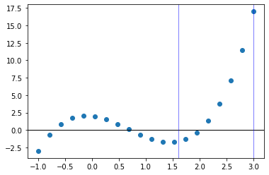

```python
a, b = 1.6, 3
plt.scatter(X, polyval(X, P))
plt.gca().axhline(0, c='k', lw=1)
plt.gca().axvline(a, c='b', lw=0.5)
plt.gca().axvline(b, c='b', lw=0.5)
```

```python
root = chord(f, a, b, EPS)
root
```

```
Chord method.
it 1: a=1.6, b=3.0, c=1.723723723723724, f(c)=-1.365480839441286 -> [c,b]
it 2: a=1.723723723723724, b=3.0, c=1.8186153748775602, f(c)=-1.0184245650052546 -> [c,b]
it 3: a=1.8186153748775602, b=3.0, c=1.885388755569285, f(c)=-0.7002038186237356 -> [c,b]
it 4: a=1.885388755569285, b=3.0, c=1.9294817534595223, f(c)=-0.45454649055224605 -> [c,b]
it 5: a=1.9294817534595223, b=3.0, c=1.9573598946819541, f(c)=-0.28409036322645553 -> [c,b]
it 6: a=1.9573598946819541, b=3.0, c=1.9744972736246427, f(c)=-0.17334914559498138 -> [c,b]
it 7: a=1.9744972736246427, b=3.0, c=1.984848779316128, f(c)=-0.10422902509434495 -> [c,b]
it 8: a=1.984848779316128, b=3.0, c=1.9910348647514893, f(c)=-0.06211439866066781 -> [c,b]
it 9: a=1.9910348647514893, b=3.0, c=1.9947079887958608, f(c)=-0.03682033177789368 -> [c,b]
it 10: a=1.9947079887958608, b=3.0, c=1.9968806468779068, f(c)=-0.021757689648332246 -> [c,b]
it 11: a=1.9968806468779068, b=3.0, c=1.9981628622615, f(c)=-0.01283297596989419 -> [c,b]
it 12: a=1.9981628622615, b=3.0, c=1.9989185595596812, f(c)=-0.007560729504341612 -> [c,b]
it 13: a=1.9989185595596812, b=3.0, c=1.9993635913960135, f(c)=-0.004451620616126917 -> [c,b]
it 14: a=1.9993635913960135, b=3.0, c=1.9996255494858814, f(c)=-0.0026200319983353815 -> [c,b]
it 15: a=1.9996255494858814, b=3.0, c=1.9997797029672701, f(c)=-0.0015416910042302945 -> [c,b]
it 16: a=1.9997797029672701, b=3.0, c=1.9998704024263079, f(c)=-0.0009070486559497049 -> [c,b]
it 17: a=1.9998704024263079, b=3.0, c=1.999923762297323, f(c)=-0.0005336174221270973 -> [c,b]
it 18: a=1.999923762297323, b=3.0, c=1.999955152965163, f(c)=-0.000313913153987766 -> [c,b]
it 19: a=1.999955152965163, b=3.0, c=1.9999736189319481, f(c)=-0.00018466190871402333 -> [c,b]
it 20: a=1.9999736189319481, b=3.0, c=1.9999844815657348, f(c)=-0.00010862711328929464 -> [c,b]
it 21: a=1.9999844815657348, b=3.0, c=1.9999908714542582, f(c)=-6.389915355109466e-05 -> [c,b]
it 22: a=1.9999908714542582, b=3.0, c=1.9999946302481797, f(c)=-3.758803206865835e-05 -> [c,b]
it 23: a=1.9999946302481797, b=3.0, c=1.9999968413158737, f(c)=-2.2110709065881196e-05 -> [c,b]
it 24: a=1.9999968413158737, b=3.0, c=1.9999981419482358, f(c)=-1.3006334730558677e-05 -> [c,b]
it 25: a=1.9999981419482358, b=3.0, c=1.9999989070275856, f(c)=-7.650797343661253e-06 -> [c,b]
it 26: a=1.9999989070275856, b=3.0, c=1.9999993570747778, f(c)=-4.5004732482922805e-06 -> [c,b]
it 27: a=1.9999993570747778, b=3.0, c=1.9999996218085985, f(c)=-2.647338666506016e-06 -> [c,b]
it 28: a=1.9999996218085985, b=3.0, c=1.999999777534437, f(c)=-1.557258545670237e-06 -> [c,b]
Chord method finished. |c-c_prev| < eps
```

```
1.9999998691378926
```

Ітерацій трохи менше, ніж було, але все ще більше, ніж в інших випадках.

## 2.3. Метод Ньютона!

**Вхід:**

- Початкове наближення $x_0$  
  (Часто беруть один з кінців інтервалу, що містить гарантовано один корінь)
- Точність $\varepsilon$
- Похідна $f'$

*Рекомендовано:*

- Монотонність
- Знакосталість другої похідної
- Відслідковувати щоб дотична, проведена у відповідній точці, не перетнула вісь абцис *поза* заданим інтервалом

**Вихід**:

- Наближений корінь $x^*$ з точністю $|x^* - x_{true}| < \varepsilon$

```python
def newton(f, df, a, b, x0, eps, timeout=1000):
    a, b = float(a), float(b)

    x_old = fx = np.inf
    x = float(x0)
    n = 1
    log("Newton method.")
    while np.abs(x-x_old) > eps and np.abs(fx) > eps and n < timeout:
        x_old, fx = x, f(x)
        x = x_old - f(x_old) / df(x_old)
        log(f"it {n}: x_old={x_old}, x={x}, f(x)={fx}")
        if x > b or x < a:
            log(ValueError(f"x out of [{a},{b}]! Terminating."))
            return np.nan
        n += 1
    log("Finished. ", end='')
    if np.abs(x-x_old) < eps:
        log("|x-x_old| < eps")
    elif np.abs(fx) < eps:
        log("|f(x)| < eps")
    else:
        log("timeout :(")

    return x
```

```python
roots = []
for i in range(len(init_borders)-1):
    r = newton(f, df, init_borders[i], init_borders[i+1], init_borders[i], EPS)
    if r != r:
        # r is nan. try other bound.
        log("Trying x0=b instead of a")
        r = newton(f, df, init_borders[i], init_borders[i+1], init_borders[i+1], EPS)
    roots.append(r)

print("\nКорені, уточнені методом Ньютона: ", roots)
Results['newton'] = roots
```

```
Newton method.
it 1: x_old=-1.0, x=-0.7692307692307692, f(x)=-3.0
it 2: x_old=-0.7692307692307692, x=-0.7108717251477279, f(x)=-0.5079654073736908
it 3: x_old=-0.7108717251477279, x=-0.7071219452226626, f(x)=-0.02894457171113629
it 4: x_old=-0.7071219452226626, x=-0.7071067814340813, f(x)=-0.00011611070975270366
it 5: x_old=-0.7071067814340813, x=-0.7071067811865475, f(x)=-1.8953305591651315e-09
Finished. |x-x_old| < eps
Newton method.
it 1: x_old=0.0, x=2.0, f(x)=2.0
x out of [0.0,1.0]! Terminating.
Trying x0=b instead of a
Newton method.
it 1: x_old=1.0, x=0.6666666666666667, f(x)=-1.0
it 2: x_old=0.6666666666666667, x=0.7070707070707071, f(x)=0.14814814814814792
it 3: x_old=0.7070707070707071, x=0.7071067811002524, f(x)=0.000131918099472772
it 4: x_old=0.7071067811002524, x=0.7071067811865476, f(x)=3.155689043410348e-10
Finished. |x-x_old| < eps
Newton method.
it 1: x_old=1.0, x=0.6666666666666667, f(x)=-1.0
x out of [1.0,3.0]! Terminating.
Trying x0=b instead of a
Newton method.
it 1: x_old=3.0, x=2.413793103448276, f(x)=17.0
it 2: x_old=2.413793103448276, x=2.112861825439257, f(x)=4.408052810693345
it 3: x_old=2.112861825439257, x=2.0121200357344824, f(x)=0.8948103320400951
it 4: x_old=2.0121200357344824, x=2.0001643246947522, f(x)=0.08601897302276917
it 5: x_old=2.0001643246947522, x=2.0000000308510675, f(x)=0.0011504888929825263
it 6: x_old=2.0000000308510675, x=2.000000000000001, f(x)=2.1595747989877623e-07
Finished. |x-x_old| < eps

Корені, уточнені методом Ньютона:  [-0.7071067811865475, 0.7071067811865476, 2.000000000000001]
```

# 3. Аналіз результатів

## 3.1. Точність

Можна знайти корені аналітично: $x_1 = -\frac{\sqrt{2}}{2}; \; x_2 = \frac{\sqrt{2}}{2};\; x_3 = 2 $

```python
true_roots = np.array([-np.sqrt(2)/2, np.sqrt(2)/2, 2.0])

np_results = np.array(list(Results.values()))
Deltas = np_results - true_roots
print("Існинні корені:\n", true_roots)
print("Результати: \n", np_results)
print("Відхилення: \n", Deltas)
print("Відносні відхилення: \n", Deltas / np.abs(true_roots))
```

```
Існинні корені:
 [-0.70710678  0.70710678  2.        ]
Результати:
 [[-0.7071068   0.7071068   2.        ]
 [-0.70710675  0.70710679  1.99999991]
 [-0.70710678  0.70710678  2.        ]]
Відхилення:
 [[-1.77007052e-08  1.77007052e-08  0.00000000e+00]
 [ 2.76401907e-08  8.45877779e-09 -9.46321266e-08]
 [ 1.11022302e-16  0.00000000e+00  8.88178420e-16]]
Відносні відхилення:
 [[-2.50325774e-08  2.50325774e-08  0.00000000e+00]
 [ 3.90891325e-08  1.19625183e-08 -4.73160633e-08]
 [ 1.57009246e-16  0.00000000e+00  4.44089210e-16]]
```

## 3.2. Кількість ітерацій

- Ньютон збігався швидше за всіх
- Метод Хорд в середньому працював швидше методу Бісекцій, але на третьому інтервалі збігався значно довше
- Метод Бісекцій працював довше за всіх (крім третього інтервала в методі Хорд)

## Отже

Метод Ньютона показав себе найшвидшим, проте він єдиний потребує похідної